# DS1_C5_S2_Challenge_KushagraSindhi

```python
from itertools import combinations as com
```

```python
# task 1

members = ['Ava']
for i in range(11):
    members.append('Member' + str(i+2))

len(list(com(members, 1))) * len(list(com(members, 4)))
```

```
5940
```

```python
# task 2

total = 150
car = 80
van = 50
lorry = 20

print(f"""
a) Probability of car leaving first = {van}/{total}
b) Probability of lorry leaving first = {lorry}/{total}
c) Probability of car leaving second if either lorry or van left first = ({van}/{total} + {lorry}/{total}) * {car}/{total}""")
```

[output not shown]

# task 3

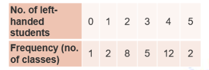

### a) 2 left handed children

probability that there are two left handed children = 8/30 => 4/15

### b) probability that there are at least 3 left handed children

probability that there are at least 3 left handed children = (5+12+2)/30 => 19/30

# Task 4

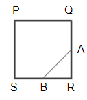

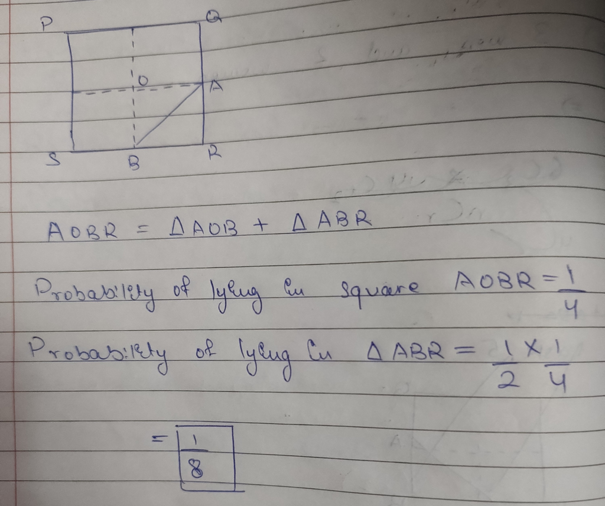

# task 5

a) Since the the smallest number on a dice is 1 and 2 dices are being rolled, the probability of the getting sum as 1 is 0

b) favourable_outcomes = [[1, 3], [2, 2], [3, 1]]

```
total_outcomes   = 36
probability      = 3/36
```

c) Since hightest number on a dice is 6 and 2 are being rolled, maximum number possible to achieve through sum is 12 and the question's requirement is less than 13.

Therefore, the favourable outcomes are 36 and total possible outcomes are also 36.

Hence, probability is 36/36, ie, 1.

# task 6

20 tickets from number 1 to 20

a) probability that the ticket selected is even = 10/20 (Since there are 10 even numbers till 20)

b) probability of selecting a number divisible by 3

```
numbers divisible by 3 range 1 to 20 = [3, 6, 9, 12, 15, 18]     = 6 numbers
probability of selecting a number divisible by 3                 = 6/20
```

c) probability of selecting a prime number

```
prime numbers between 1 and 20 = [2, 3, 5, 7, 11, 13, 17, 19]    = 8 numbers
probability of selecting a prime number                          = 8/20
                                                                 = 4/10
                                                                 = 2/5
```

d) probability of selecting a number divisible by 5

```
numbers divisible by 5 = [5, 10, 15, 20]                         = 4 numbers
probability of selecting a number divisible by 5                 = 4/20
                                                                 = 2/10
                                                                 = 1/5
```

# task 7

3 dice

11 or 12 as sum more likely

all possible outcomes = 6^3 = 216

probability of 11 => 27/216

probability of 12 => 25/216

Sum of 11 from a rolling of 3 dices is more likely to occur